# Determining the Best Value Ski Hotels in Europe

Ben Kagan  
CMSC320  
Maksym Morawski  
December 16th, 2022

## Introduction

Europe contains a vast number of ski resorts, ranging from beginner-friendly resorts suitable for a day-trip to mega resorts that have hosted international competitions. Many ski resorts play host to numerous hotels that market its proximity to the resort as a luxury. A wide variety of factors can help determine the value of one ski hotel over another. In addition to the standard factors including, but not limited to, price, customer reviews, and hotel quality, the value of a ski hotel heavily depends on factor such as the proximity to the ski resort and the ski resort's overall quality to name a few.

In this tutorial, we will analyze data on over 400 ski hotels in Europe by performing data exploration and subsequently regression analysis and value determination.

## Data Collection

The data obtained for this tutorial can be found on the following Kaggle page: [Skiing Hotels](https://www.kaggle.com/datasets/jacklacey/skiing-hotels).

To start, we will import all the libraries used in this tutorial:

```python
import pandas as pd
import numpy as np
from selenium import webdriver
from selenium.webdriver.common.by import By
import time

import matplotlib.pyplot as plt
import seaborn as sns

import statsmodels.api as sm

from sklearn.ensemble import RandomForestClassifier
from sklearn.model_selection import StratifiedKFold
```

```python
hotels_df = pd.read_csv("ski_hotels.csv")
hotels_df = hotels_df.iloc[: , 1:]
hotels_df = hotels_df.dropna(how='all')
hotels_df
```

|  | country | resort | hotel | price (£) | distance_from_lift_(m) | altitude (m) | totalPiste (km) | totalLifts | gondolas | chairlifts | ... | blacks | totalRuns | link | sleeps | decSnowLow2020(cm) | decSnowHigh2020(cm) | janSnowLow2020(cm) | janSnowHigh2020(cm) | febSnowLow2020(cm) | febSnowHigh2020(cm) |
| --- | --- | --- | --- | --- | --- | --- | --- | --- | --- | --- | --- | --- | --- | --- | --- | --- | --- | --- | --- | --- | --- |
| 0 | italy | bardonecchia | residence-tabor | 550 | unknown | 1312 | 140 | 23 | 0 | 9 | ... | 1.0 | 42.0 | https://www.igluski.com/ski-resorts/italy/bard... | unknown | 70 | 170 | 60 | 200 | 47 | 177 |
| 1 | italy | bardonecchia | residence-villa-frejus | 561 | unknown | 1312 | 140 | 23 | 0 | 9 | ... | 1.0 | 42.0 | https://www.igluski.com/ski-resorts/italy/bard... | unknown | 70 | 170 | 60 | 200 | 47 | 177 |
| 2 | bulgaria | bansko | hotel-mura | 566 | 1100 | 935 | 70 | 24 | 1 | 7 | ... | 1.0 | 14.0 | https://www.igluski.com/ski-resorts/bulgaria/b... | 140 | 0 | 70 | 5 | 75 | 5 | 77 |
| 3 | bulgaria | borovets | hotel-samokov | 574 | 75 | 1390 | 58 | 18 | 1 | 4 | ... | 1.0 | 15.0 | https://www.igluski.com/ski-resorts/bulgaria/b... | 590 | 0 | 0 | 160 | 200 | 194 | 246 |
| 4 | bulgaria | bansko | hotel-lion---bansko | 596 | 800 | 935 | 70 | 24 | 1 | 7 | ... | 1.0 | 14.0 | https://www.igluski.com/ski-resorts/bulgaria/b... | 386 | 0 | 70 | 5 | 75 | 5 | 77 |
| ... | ... | ... | ... | ... | ... | ... | ... | ... | ... | ... | ... | ... | ... | ... | ... | ... | ... | ... | ... | ... | ... |
| 402 | france | val-thorens | hotel-fitz-roy | 2216 | unknown | 2300 | 600 | 183 | 40 | 69 | ... | 32.0 | 321.0 | https://www.igluski.com/ski-resorts/france/val... | 112 | 98 | 121 | 215 | 267 | 207 | 269 |
| 403 | austria | ischgl | hotel-fliana | 2258 | unknown | 1400 | 230 | 48 | 9 | 27 | ... | 15.0 | 98.0 | https://www.igluski.com/ski-resorts/austria/is... | 30 | 20 | 70 | 50 | 120 | 63 | 131 |
| 404 | austria | ischgl | hotel-elisabeth | 2420 | unknown | 1400 | 230 | 48 | 9 | 27 | ... | 15.0 | 98.0 | https://www.igluski.com/ski-resorts/austria/is... | 110 | 20 | 70 | 50 | 120 | 63 | 131 |
| 405 | austria | ischgl | hotel-trofana-royal | 2484 | unknown | 1400 | 230 | 48 | 9 | 27 | ... | 15.0 | 98.0 | https://www.igluski.com/ski-resorts/austria/is... | 164 | 20 | 70 | 50 | 120 | 63 | 131 |
| 406 | austria | hinterglemm | hotel-alpine-palace | 2517 | 20 | 1003 | 200 | 54 | 15 | 16 | ... | 5.0 | 64.0 | https://www.igluski.com/ski-resorts/austria/hi... | 262 | 5 | 50 | 50 | 133 | 46 | 140 |

407 rows × 23 columns

For convenience's sake, I will add a column labelled 'price ($)' to display the nightly price of the hotel in USD as opposed to in British pounds. As of December 14th, 2022. The conversion rate from 1 Pound sterling to United States Dollar is 1.23.

```python
hotels_df['price ($)'] = hotels_df['price (£)'].apply(lambda x: x*1.23)
```

### Column Descriptions

Next, we need to determine the meaning of every column in our dataset in order further explore the data. Provided below is a list giving a description on each column of the dataset:

- country: The country of the hotel and ski resort
- resort: The name of the ski resort in which the hotel is located
- hotel: The name of the hotel
- price (£): The nightly price for a room in the hotel in British pounds
- distance_from_lift_(m): The distance from the hotel to the nearest ski resort lift in meters
- altitude (m): The altitude of the hotel in meters
- totalPiste (km): The total distance of regularly maintained, skiable on the resort, in kilometers
- totalLifts: The total number of lifts in the ski resort
- gondolas: The number of gondolas in the ski resort
- chairLifts: The number of chair lifts in the ski resort
- dragLifts: The number of drag lifts in the ski resort
- blues: The number of blue-graded slopes in the ski resort
- reds: The number of red-graded slopes in the ski resort
- blacks: The number of black-graded slopes in the ski resort
- totalRuns: The total number of slopes in the ski resort
- link: the URL to the hotel's website
- sleeps: the total occupancy of the hotel
- decSnowLow2020(cm): The smallest snowfall received, in centimeters, from the month of December 2020 at the resort
- decSnowHigh2020(cm): The largest snowfall received, in centimeters, from the month of December 2020 at the resort
- janSnowLow2020(cm): The smallest snowfall received, in centimeters, from the month of January 2020 at the resort
- janSnowHigh2020(cm): The largest snowfall received, in centimeters, from the month of January 2020 at the resort
- febSnowLow2020(cm): The smallest snowfall received, in centimeters, from the month of February 2020 at the resort
- febSnowHigh2020(cm): The largest snowfall received, in centimeters, from the month of February 2020 at the resort
- price ($): The nightly price for a room in the hotel in USD

### Web Scraping

Upon further inspection, it appears that the provided dataset is missing some vital data about the ski hotels, such as customer reviews. To remedy this, we will go ahead and scrape the Google ratings, on a 5-star scale, for each hotel in the dataset.

To achieve this, we will use the Selenium package to run a Chrome WebDriver to search into google the name of the hotel with the resort name. We will then parse the DOM Selenium's built-in `find_element()` function as well as XPath to retrieve the html element containing the star rating and the number of reviews. If a particular hotel search provides an abnormal result, the field is filled as unknown and consequently retrieved manually.

```python
def scrape_google_results(driver, hotel, resort, tag):
    url = f"https://www.google.com/search?q={hotel}+{resort}"
    driver.get(url)
    time.sleep(3)
    try:
        element = driver.find_element(By.XPATH, '//div[@id="rhs"]/div/div/div[@class="I6TXqe"]/div/div[1]/div/div[2]/div[@class="wDYxhc"][1]/div/div').find_elements(By.TAG_NAME, tag)[0]
    except:
        return 'unknown'
    return element.text

def get_rating(driver, hotel, resort):
    return scrape_google_results(driver, hotel, resort, 'span')

def get_num_reviews(driver, hotel, resort):
    return scrape_google_results(driver, hotel, resort, 'a').split(" ")[0]

driver = webdriver.Chrome()

hotels_df['ratings'] = hotels_df.apply(lambda x: get_rating(driver, x.hotel, x.resort), axis=1)
hotels_df['num_reviews'] = hotels_df.apply(lambda x: get_num_reviews(driver, x.hotel, x.resort), axis=1)
```

### Missing/Unknown Data

Let's examine the data and determine how many rows contain unknown values. We will use this to decide what needs to be researched or dropped.

```python
hotels_df = hotels_df.replace('unknown', np.nan)
hotels_df = hotels_df.astype({'price (£)': 'float64',
                              'distance_from_lift_(m)': 'float64',
                              'altitude (m)': 'float64',
                              'totalPiste (km)': 'float64',
                              'blues': 'int64',
                              'reds': 'int64',
                              'blacks': 'int64',
                              'totalRuns': 'int64',
                              'sleeps': 'int64',
                              'decSnowLow2020(cm)': 'float64',
                              'decSnowHigh2020(cm)': 'float64',
                              'janSnowLow2020(cm)': 'float64',
                              'janSnowHigh2020(cm)': 'float64',
                              'febSnowLow2020(cm)': 'float64',
                              'febSnowHigh2020(cm)': 'float64',
                              'ratings': 'float64'}, errors='ignore')
for index, row in hotels_df.iterrows():
    try:
        hotels_df.at[index, 'num_reviews'] = int(row.num_reviews)
    except Exception as e:
        if row.num_reviews=='CHECK':
            hotels_df.at[index, 'num_reviews'] = np.nan
        elif type(row.num_reviews)==str:
            hotels_df.at[index, 'num_reviews'] = int(row.num_reviews.replace(",",""))
hotels_df = hotels_df.astype({'num_reviews': 'int64'}, errors='ignore')
```

The following line displays all hotels that had an abnormal hotel search, resulting in a missing rating and review count:

```python
hotels_df[hotels_df[['ratings', 'num_reviews']].isna().any(axis=1)]
```

|  | country | resort | hotel | price (£) | distance_from_lift_(m) | altitude (m) | totalPiste (km) | totalLifts | gondolas | chairlifts | ... | sleeps | decSnowLow2020(cm) | decSnowHigh2020(cm) | janSnowLow2020(cm) | janSnowHigh2020(cm) | febSnowLow2020(cm) | febSnowHigh2020(cm) | price ($) | ratings | num_reviews |
| --- | --- | --- | --- | --- | --- | --- | --- | --- | --- | --- | --- | --- | --- | --- | --- | --- | --- | --- | --- | --- | --- |
| 8 | andorra | arinsal | hotel-xalet-verdu | 606.0 | 300.0 | 1550.0 | 63.0 | 30 | 2 | 11 | ... | 104 | 30.0 | 60.0 | 130.0 | 180.0 | 120.0 | 170.0 | 745.38 | NaN | NaN |
| 19 | italy | sauze-d-oulx | hotel-clotes | 692.0 | 100.0 | 1503.0 | 400.0 | 89 | 0 | 35 | ... | NaN | 150.0 | 220.0 | 35.0 | 300.0 | 96.0 | 280.0 | 851.16 |  | NaN |
| 28 | austria | bad-hofgastein | apartments-aurora | 704.0 | NaN | 870.0 | 208.0 | 49 | 11 | 19 | ... | NaN | 0.0 | 100.0 | 48.0 | 155.0 | 45.0 | 176.0 | 865.92 | NaN | NaN |
| 39 | finland | pyha | pyha-suites | 737.0 | NaN | 280.0 | 80.0 | 9 | 0 | 0 | ... | 4 | 40.0 | 50.0 | 60.0 | 70.0 | 64.0 | 74.0 | 906.51 | NaN | NaN |
| 55 | austria | niederau-oberau | hotel-austria | 761.0 | NaN | 826.0 | 48.0 | 47 | 7 | 8 | ... | 94 | 0.0 | 0.0 | 50.0 | 106.0 | 48.0 | 114.0 | 936.03 | NaN | NaN |
| 63 | bulgaria | pamporovo | hotel-orlovetz | 772.0 | 3000.0 | 1650.0 | 18.0 | 19 | 0 | 6 | ... | 210 | 0.0 | 0.0 | 60.0 | 85.0 | 166.0 | 170.0 | 949.56 | NaN | NaN |
| 70 | austria | kitzbuhel | hotel-bruggerhof | 783.0 | 2000.0 | 760.0 | 185.0 | 61 | 11 | 27 | ... | 56 | NaN | NaN | NaN | NaN | NaN | NaN | 963.09 | NaN | NaN |
| 73 | finland | yllas | yllas-saaga-spa-hotel | 785.0 | NaN | 719.0 | 0.0 | 29 | 1 | 1 | ... | 168 | 40.0 | 65.0 | 85.0 | 85.0 | 85.0 | 85.0 | 965.55 | NaN | NaN |
| 78 | italy | courmayeur | hotel-courmayeur | 795.0 | NaN | 1224.0 | 100.0 | 16 | 5 | 8 | ... | 70 | 40.0 | 100.0 | 40.0 | 100.0 | 41.0 | 117.0 | 977.85 | NaN | NaN |
| 126 | italy | sauze-d-oulx | hotel-new-miravalle | 879.0 | NaN | 1503.0 | 400.0 | 89 | 0 | 35 | ... | NaN | 150.0 | 220.0 | 35.0 | 300.0 | 96.0 | 280.0 | 1081.17 |  | NaN |
| 171 | italy | selva-val-gardena | hotel-pralong | 967.0 | 150.0 | 1563.0 | 175.0 | 81 | 9 | 41 | ... | 54 | 72.0 | 165.0 | 50.0 | 150.0 | 49.0 | 149.0 | 1189.41 | NaN | NaN |
| 176 | andorra | soldeu | sporthotel | 978.0 | 50.0 | 1800.0 | 210.0 | 67 | 4 | 32 | ... | 330 | NaN | NaN | NaN | NaN | NaN | NaN | 1202.94 | NaN | NaN |
| 183 | france | tignes | hotel-diva | 990.0 | 300.0 | 2100.0 | 300.0 | 89 | 10 | 45 | ... | 242 | 75.0 | 165.0 | 185.0 | 233.0 | 191.0 | 242.0 | 1217.70 | NaN | NaN |
| 212 | austria | mayrhofen | hotel-rose | 1042.0 | 500.0 | 630.0 | 600.0 | 52 | 8 | 27 | ... | 96 | 0.0 | 60.0 | 5.0 | 80.0 | 2.0 | 99.0 | 1281.66 |  | NaN |
| 217 | andorra | soldeu | hotel-xalet-montana | 1051.0 | NaN | 1800.0 | 210.0 | 67 | 4 | 32 | ... | 80 | NaN | NaN | NaN | NaN | NaN | NaN | 1292.73 |  | NaN |
| 220 | france | alpe-d-huez | prestige-apart-hotel-l-eclose | 1062.0 | 200.0 | 1850.0 | 249.0 | 82 | 15 | 23 | ... | 150 | 71.0 | 120.0 | 151.0 | 276.0 | 141.0 | 241.0 | 1306.26 | NaN | NaN |
| 228 | finland | levi | hotel-crazy-reindeer | 1079.0 | NaN | 200.0 | 44.0 | 27 | 2 | 2 | ... | 314 | 35.0 | 45.0 | 65.0 | 75.0 | 90.0 | 115.0 | 1327.17 | NaN | NaN |
| 249 | austria | saalbach | landhaus-bauer | 1143.0 | 200.0 | 1003.0 | 270.0 | 70 | 28 | 22 | ... | NaN | 5.0 | 50.0 | 50.0 | 133.0 | 46.0 | 140.0 | 1405.89 | NaN | NaN |
| 253 | france | tignes | hotel-arbina | 1157.0 | 120.0 | 2100.0 | 300.0 | 89 | 10 | 45 | ... | 50 | 75.0 | 165.0 | 185.0 | 233.0 | 191.0 | 242.0 | 1423.11 | NaN | NaN |
| 269 | france | belle-plagne | hotel-club-mmv-deux-domaines | 1184.0 | NaN | 2050.0 | 425.0 | 139 | 15 | 66 | ... | 300 | NaN | NaN | NaN | NaN | NaN | NaN | 1456.32 | NaN | NaN |
| 279 | france | alpe-d-huez | hotel-royal-ours-blanc | 1199.0 | 100.0 | 1850.0 | 249.0 | 82 | 15 | 23 | ... | NaN | 71.0 | 120.0 | 151.0 | 276.0 | 141.0 | 241.0 | 1474.77 |  | NaN |
| 282 | austria | soll | hotel-postwirt | 1213.0 | 800.0 | 703.0 | 250.0 | 94 | 11 | 38 | ... | 124 | 0.0 | 25.0 | 33.0 | 76.0 | 48.0 | 85.0 | 1491.99 | NaN | NaN |
| 295 | france | tignes-val-claret | hotel-val-claret | 1243.0 | 50.0 | 2100.0 | 300.0 | 89 | 10 | 45 | ... | 514 | NaN | NaN | NaN | NaN | NaN | NaN | 1528.89 | NaN | NaN |
| 298 | austria | obergurgl | hotel-haus-gurgl | 1249.0 | 200.0 | 1930.0 | 110.0 | 24 | 3 | 12 | ... | 46 | 100.0 | 185.0 | 69.0 | 143.0 | 60.0 | 133.0 | 1536.27 | NaN | NaN |
| 326 | austria | ischgl | hotel-seiblishof | 1339.0 | 500.0 | 1400.0 | 230.0 | 48 | 9 | 27 | ... | 114 | 20.0 | 70.0 | 50.0 | 120.0 | 63.0 | 131.0 | 1646.97 | NaN | NaN |
| 349 | austria | st-anton | hotel-galzig | 1424.0 | NaN | 1304.0 | 305.0 | 88 | 15 | 45 | ... | NaN | 35.0 | 45.0 | 110.0 | 138.0 | 102.0 | 168.0 | 1751.52 | NaN | NaN |

26 rows × 26 columns

We will go ahead and manually Google search for each hotel listed above to retrieve their Google star rating and number of reviews. In addition, we will research and input any valuable missing data besides ratings and number of reviews.

```python
hotels_df.at[8,'ratings'], hotels_df.at[8,'num_reviews'] = 4.3, 931
hotels_df.at[19,'ratings'], hotels_df.at[19,'num_reviews'] = 4.2, 32
hotels_df.at[28,'ratings'], hotels_df.at[28,'num_reviews'] = 4.3, 25
hotels_df.at[39,'ratings'], hotels_df.at[39,'num_reviews'] = 4.3, 24
hotels_df.at[55,'ratings'], hotels_df.at[55,'num_reviews'] = 3.8, 227
hotels_df.at[63,'ratings'], hotels_df.at[63,'num_reviews'] = np.nan, np.nan # no hotel listing on Google
hotels_df.at[70,'ratings'], hotels_df.at[70,'num_reviews'] = 4.2, 122
hotels_df.at[73,'ratings'], hotels_df.at[73,'num_reviews'] = 4.3, 826
hotels_df.at[117,'ratings'], hotels_df.at[117,'num_reviews'] = 4.8, 390
hotels_df.at[126,'ratings'], hotels_df.at[126,'num_reviews'] = 4.1, 61
hotels_df.at[159,'ratings'], hotels_df.at[159,'num_reviews'] = 4.6, 245
hotels_df.at[161,'ratings'], hotels_df.at[161,'num_reviews'] = 4.2, 520
hotels_df.at[171,'ratings'], hotels_df.at[171,'num_reviews'] = 4.7, 64
hotels_df.at[176,'ratings'], hotels_df.at[176,'num_reviews'] = 4.6, 122
hotels_df.at[190,'ratings'], hotels_df.at[190,'num_reviews'] = 4.6, 86
hotels_df.at[212,'ratings'], hotels_df.at[212,'num_reviews'] = 4.5, 557
hotels_df.at[217,'ratings'], hotels_df.at[217,'num_reviews'] = np.nan, np.nan # no reviews posted for Google listing
hotels_df.at[220,'ratings'], hotels_df.at[220,'num_reviews'] = np.nan, np.nan # no reviews posted for Google listing
hotels_df.at[228,'ratings'], hotels_df.at[228,'num_reviews'] = 4.2, 200
hotels_df.at[242,'ratings'], hotels_df.at[242,'num_reviews'] = 4.5, 73
hotels_df.at[249,'ratings'], hotels_df.at[249,'num_reviews'] = 4.0, 1
hotels_df.at[253,'ratings'], hotels_df.at[253,'num_reviews'] = 3.3, 282
hotels_df.at[269,'ratings'], hotels_df.at[269,'num_reviews'] = 4.3, 81
hotels_df.at[279,'ratings'], hotels_df.at[279,'num_reviews'] = 3.9, 151
hotels_df.at[282,'ratings'], hotels_df.at[282,'num_reviews'] = np.nan, np.nan # no reviews posted for Google listing
hotels_df.at[295,'ratings'], hotels_df.at[295,'num_reviews'] = 4.0, 67
hotels_df.at[326,'ratings'], hotels_df.at[326,'num_reviews'] = np.nan, np.nan # no reviews posted for Google listing
hotels_df.at[349,'ratings'], hotels_df.at[349,'num_reviews'] = 4.7, 71

hotels_df.loc[hotels_df['resort']=='galtur', 'blues'] = 6
hotels_df.loc[hotels_df['resort']=='galtur', 'reds'] = 25
hotels_df.loc[hotels_df['resort']=='galtur', 'blacks'] = 12
hotels_df.loc[hotels_df['resort']=='galtur', 'totalRuns'] = 43

hotels_df.loc[hotels_df['resort']=='ortisei-st-ulrich', 'blues'] = 52
hotels_df.loc[hotels_df['resort']=='ortisei-st-ulrich', 'reds'] = 105
hotels_df.loc[hotels_df['resort']=='ortisei-st-ulrich', 'blacks'] = 21
hotels_df.loc[hotels_df['resort']=='ortisei-st-ulrich', 'totalRuns'] = 178

hotels_df.loc[hotels_df['resort']=='zurs-am-arlberg', 'blues'] = 130
hotels_df.loc[hotels_df['resort']=='zurs-am-arlberg', 'reds'] = 122
hotels_df.loc[hotels_df['resort']=='zurs-am-arlberg', 'blacks'] = 50
hotels_df.loc[hotels_df['resort']=='zurs-am-arlberg', 'totalRuns'] = 302

hotels_df.loc[hotels_df['resort']=='hochgurgl', 'blues'] = 60
hotels_df.loc[hotels_df['resort']=='hochgurgl', 'reds'] = 33
hotels_df.loc[hotels_df['resort']=='hochgurgl', 'blacks'] = 19
hotels_df.loc[hotels_df['resort']=='hochgurgl', 'totalRuns'] = 112
```

We will drop the entries with no reviews, as that predictor is vital for our assessments:

```python
hotels_df = hotels_df.dropna(subset=['ratings', 'num_reviews'])
hotels_df = hotels_df.astype({'ratings': 'float64', 'num_reviews': 'int64'})
```

Furthermore, we will create 2 new columns, titled `relative_score`, which contains of the product of the values in the `ratings` and `num_reviews` columns, and `value_metric` which is the quotient of the values in the `relative_score` and `price ($)` columns. Its uses will be further examined.

```python
hotels_df['relative_score'] = hotels_df.apply(lambda x: x['ratings'] * x['num_reviews'], axis=1)
hotels_df['value_metric'] = hotels_df.apply(lambda x: x['relative_score'] / x['price ($)'], axis=1)
hotels_df['proportion_blues'] = hotels_df.apply(lambda x: x['blues'] / x['totalRuns'] if x['totalRuns']!=0 else 0, axis=1)
hotels_df['proportion_reds'] = hotels_df.apply(lambda x: x['blues'] / x['totalRuns'] if x['totalRuns']!=0 else 0, axis=1)
hotels_df['proportion_blacks'] = hotels_df.apply(lambda x: x['blacks'] / x['totalRuns'] if x['totalRuns']!=0 else 0, axis=1)
```

Due to the computational intensity of the web scraping in order to complete the dataset. I will save the DataFrame to a fresh .csv file in the event of data loss:

```python
hotels_df.to_csv('ski_hotels_complete.csv' ,index=False)
```

## Data Exploration

Now that we have fully acquired the data on European Ski Hotels, we will preform some exploration to examine the properties of the data.

To start, we will display standard statistics metrics of each numerical column in the dataset:

```python
hotels_df.describe()
```

|  | price (£) | distance_from_lift_(m) | altitude (m) | totalPiste (km) | totalLifts | gondolas | chairlifts | draglifts | blues | reds | ... | febSnowLow2020(cm) | febSnowHigh2020(cm) | price ($) | ratings | num_reviews | relative_score | value_metric | proportion_blues | proportion_reds | proportion_blacks |
| --- | --- | --- | --- | --- | --- | --- | --- | --- | --- | --- | --- | --- | --- | --- | --- | --- | --- | --- | --- | --- | --- |
| count | 399.000000 | 209.000000 | 399.000000 | 399.000000 | 399.000000 | 399.00000 | 399.000000 | 399.000000 | 399.000000 | 399.000000 | ... | 344.000000 | 344.000000 | 399.000000 | 399.000000 | 399.000000 | 399.000000 | 399.000000 | 399.000000 | 399.000000 | 399.000000 |
| mean | 1095.751880 | 349.162679 | 1354.303258 | 221.010025 | 60.506266 | 9.14787 | 24.784461 | 25.238095 | 42.355890 | 47.295739 | ... | 68.555233 | 174.959302 | 1347.774812 | 4.377945 | 312.147870 | 1354.087719 | 1.118070 | 0.395131 | 0.395131 | 0.137649 |
| std | 345.158599 | 345.999309 | 508.848365 | 165.662595 | 39.171756 | 8.45239 | 17.031707 | 19.379338 | 41.117904 | 39.035968 | ... | 49.802026 | 74.001643 | 424.545077 | 0.302693 | 508.209302 | 2221.381613 | 1.908904 | 0.138421 | 0.138421 | 0.057661 |
| min | 550.000000 | 5.000000 | 180.000000 | 0.000000 | 0.000000 | 0.00000 | 0.000000 | 0.000000 | 1.000000 | 3.000000 | ... | 0.000000 | 74.000000 | 676.500000 | 2.800000 | 1.000000 | 4.000000 | 0.002845 | 0.066667 | 0.066667 | 0.000000 |
| 25% | 839.000000 | 100.000000 | 900.000000 | 110.000000 | 30.000000 | 3.00000 | 12.000000 | 12.000000 | 16.000000 | 19.000000 | ... | 45.000000 | 130.000000 | 1031.970000 | 4.200000 | 100.000000 | 440.700000 | 0.311733 | 0.272727 | 0.272727 | 0.096570 |
| 50% | 1019.000000 | 200.000000 | 1428.000000 | 185.000000 | 55.000000 | 8.00000 | 22.000000 | 21.000000 | 30.000000 | 37.000000 | ... | 50.000000 | 150.000000 | 1253.370000 | 4.400000 | 189.000000 | 814.000000 | 0.626016 | 0.404762 | 0.404762 | 0.148438 |
| 75% | 1272.000000 | 500.000000 | 1800.000000 | 292.000000 | 82.000000 | 11.50000 | 35.000000 | 32.000000 | 51.500000 | 70.000000 | ... | 90.000000 | 219.000000 | 1564.560000 | 4.600000 | 338.500000 | 1467.600000 | 1.096049 | 0.523810 | 0.523810 | 0.167763 |
| max | 2517.000000 | 2100.000000 | 2300.000000 | 1220.000000 | 206.000000 | 43.00000 | 83.000000 | 114.000000 | 186.000000 | 219.000000 | ... | 207.000000 | 400.000000 | 3095.910000 | 5.000000 | 5952.000000 | 26784.000000 | 25.058239 | 0.666667 | 0.666667 | 0.285714 |

8 rows × 26 columns

### Single-Variable Distributions

We will now create several distribution graphs to determine the skew of the most important predictors for determining the value of an European ski hotel. To start, we will display a histogram of price/night (in USD):

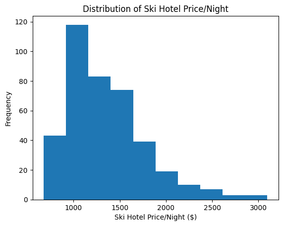

```python
plt.title("Distribution of Ski Hotel Price/Night")
plt.xlabel("Ski Hotel Price/Night ($)")
plt.ylabel("Frequency")
plt.hist(hotels_df['price ($)'].values)
```

As we can see, the distribution of price/night is skewed right such that the highest frequency of prices ranges from around $1000/night-$1250/night.

We will also plot a histogram of the distribution of relative rating scores:

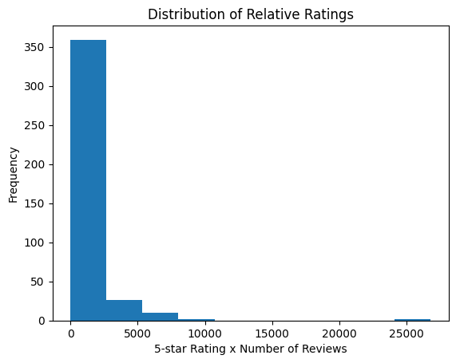

```python
plt.title("Distribution of Relative Ratings")
plt.xlabel("5-star Rating x Number of Reviews")
plt.ylabel("Frequency")
plt.hist(hotels_df['relative_score'].values)
```

Due to the overwhelming right skew, we will create another histogram, except using a logarithmic scale:

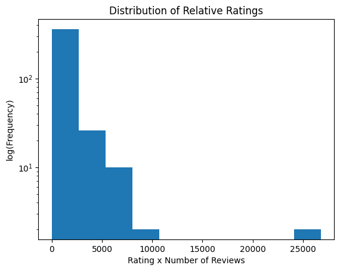

```python
plt.title("Distribution of Relative Ratings")
plt.xlabel("Rating x Number of Reviews")
plt.ylabel("log(Frequency)")
plt.hist(hotels_df['relative_score'].values, log=True)
```

Even using the logarithmic scale to view relative score distributions, we see that the overwhelming majority of hotels have a score below 10000, meaning that, given the 5-star Google rating system, have under 2000 reviews

Next, we will create a distribution histogram for the hotel altitudes:

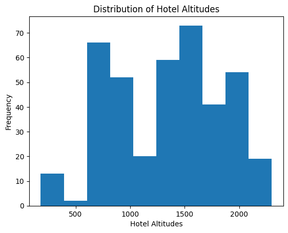

```python
plt.title("Distribution of Hotel Altitudes")
plt.xlabel("Hotel Altitudes")
plt.ylabel("Frequency")
plt.hist(hotels_df['altitude (m)'].values)
```

Unlike the previous 2 histograms, the histogram for altitude frequencies is bimodal, with the most common hotel altitudes at around 750m as well as 1600m. These values heavily depend on the hotel's ski resort.

First, we must construct a groupby object in order to partition the DataFrame for each resort. As all values in resort-dependent columns are equivalent for the same resort, it suffices to use the `mean()` function to retrieve the necessary resort-dependent values.

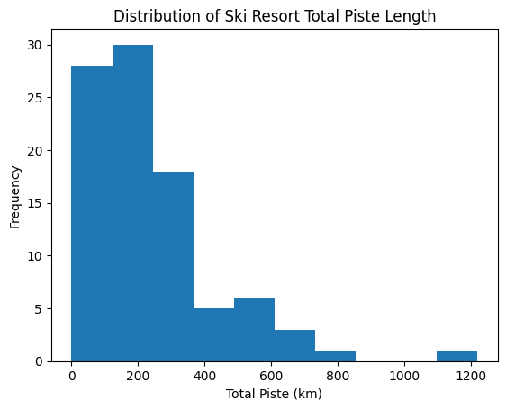

```python
resorts_df = hotels_df.groupby(['resort'])
plt.title("Distribution of Ski Resort Total Piste Length")
plt.xlabel("Total Piste (km)")
plt.ylabel("Frequency")
plt.hist(resorts_df['totalPiste (km)'].mean().values)
```

Again, we see a right skewed distribution, meaning that the majority of the available European ski resorts are on the left side of the histogram and only a select few ski resorts have more than 600km in total piste.

### Multi-variable Relationships

We will now examine the relationships, or lack thereof, of various variables in order to determine the most important factors for a high value hotel, which can be defined as a ski hotel that has the high customer satisfaction and best qualities for the lowest price. The recently calculated `relative_score` column will be treated as our customer satisfaction metric.

The plots used will be scatter plots, where we will be able to calculate a linear regression between two variables.

To do this, we will use the seaborn library to create a scatter plot with a line of best fit.

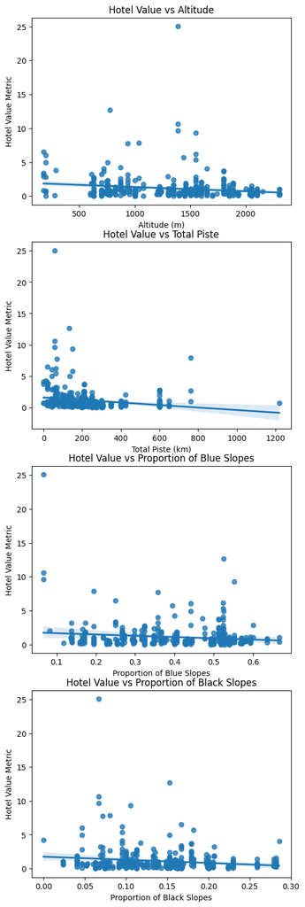

```python
fig, axes = plt.subplots(4, 1, figsize=(6, 20))

sns.regplot(x="altitude (m)", y="value_metric", data=hotels_df, ax=axes[0])
axes[0].set_xlabel("Altitude (m)")
axes[0].set_ylabel("Hotel Value Metric")
axes[0].set_title("Hotel Value vs Altitude")

sns.regplot(x="totalPiste (km)", y="value_metric", data=hotels_df, ax=axes[1])
axes[1].set_xlabel("Total Piste (km)")
axes[1].set_ylabel("Hotel Value Metric")
axes[1].set_title("Hotel Value vs Total Piste")

sns.regplot(x="proportion_blues", y="value_metric", data=hotels_df, ax=axes[2])
axes[2].set_xlabel("Proportion of Blue Slopes")
axes[2].set_ylabel("Hotel Value Metric")
axes[2].set_title("Hotel Value vs Proportion of Blue Slopes")

sns.regplot(x="proportion_blacks", y="value_metric", data=hotels_df, ax=axes[3])
axes[3].set_xlabel("Proportion of Black Slopes")
axes[3].set_ylabel("Hotel Value Metric")
axes[3].set_title("Hotel Value vs Proportion of Black Slopes")
```

It appears that as altitude of the hotel, total resort piste, and proportion of blue and black slopes increase, the value of a ski hotel slightly decreases. Naturally, smaller and lower elevation ski resorts tend to have better value hotels due to the cheaper hotel prices as a result from the less premium ski resort experience.

## Hypothesis Testing

We will utilize the statsmodel library in order to perform hypothesis testing.

The null hypothesis would be that there is no relationship between the value of a ski hotel and the total piste of the ski resort, while the alternate hypothesis would be that there is a relationship between the value of a ski hotel and the total piste of the ski resort.

```python
X = hotels_df[['totalPiste (km)']].values
y = hotels_df['value_metric'].values

model = sm.OLS(y, X)
results = model.fit()
results.summary()
```

OLS Regression Results

| Dep. Variable: | y | R-squared (uncentered): | 0.099 |
| --- | --- | --- | --- |
| Model: | OLS | Adj. R-squared (uncentered): | 0.097 |
| Method: | Least Squares | F-statistic: | 43.95 |
| Date: | Fri, 16 Dec 2022 | Prob (F-statistic): | 1.10e-10 |
| Time: | 01:55:13 | Log-Likelihood: | -861.69 |
| No. Observations: | 399 | AIC: | 1725. |
| Df Residuals: | 398 | BIC: | 1729. |
| Df Model: | 1 |  |  |
| Covariance Type: | nonrobust |  |  |

|  | coef | std err | t | P>\|t\| | [0.025 | 0.975] |
| --- | --- | --- | --- | --- | --- | --- |
| x1 | 0.0025 | 0.000 | 6.630 | 0.000 | 0.002 | 0.003 |

| Omnibus: | 509.000 | Durbin-Watson: | 1.570 |
| --- | --- | --- | --- |
| Prob(Omnibus): | 0.000 | Jarque-Bera (JB): | 56945.082 |
| Skew: | 6.028 | Prob(JB): | 0.00 |
| Kurtosis: | 60.270 | Cond. No. | 1.00 |

Notes:  
[1] R² is computed without centering (uncentered) since the model does not contain a constant.  
[2] Standard Errors assume that the covariance matrix of the errors is correctly specified.

### Analysis

An R^2 value of 0.099 for the relationship between the value of a ski hotel and the total piste of the ski resort indicates that there is a very weak relationship between the two variables. Specifically, the total piste of the ski resort is only able to explain about 9.9% of the variance in the value of a ski hotel. This means that there are likely other factors that are more strongly related to the total piste of a ski resort, such as the location, quality of the snow, and availability of other amenities.

It is important to note that an R^2 value of 0.099 is considered to be very low, and it suggests that the total piste of the ski resort is not a strong predictor of the value of a ski hotel. In order to gain a better understanding of the relationship between these two variables, it may be necessary to consider other factors that could be influencing the total piste of a ski resort.

## Classification

We will perform machine learning classification to predict the country of a hotel and corresponding ski resort using various variables.

To start, we will need to perform further clean-up to our dataset to completely handle or remove missing data

```python
classifier_columns = [
    'altitude (m)',
    'totalPiste (km)',
    'gondolas',
    'chairlifts',
    'draglifts',
    'blues',
    'reds',
    'blacks',
    'value_metric'
]

classification_hotels = hotels_df[classifier_columns + ['country']].loc[pd.notnull(hotels_df[classifier_columns]).all(axis=1)]
```

We've selected the Random Forest Classifier from the sci-kit learn package to perform this task. In addition, we will perform model selection through the Stratified K-Fold module from the sci-kit learn package in order to utilize cross-validatoin and eliminate bias.

```python
X = classification_hotels[classifier_columns[:-1]].values
Y = classification_hotels['country'].values
skf = StratifiedKFold(n_splits=10, shuffle=True, random_state=0)
scores = []
for train_index, test_index in skf.split(X, Y):
    X_train, X_test = X[train_index], X[test_index]
    Y_train, Y_test = Y[train_index], Y[test_index]
    clf = RandomForestClassifier(random_state=0)
    clf.fit(X_train, Y_train)
    scores.append(clf.score(X_test, Y_test))
scores
```

```
[0.95, 1.0, 0.975, 1.0, 0.975, 1.0, 1.0, 1.0, 1.0, 1.0]
```

With most of the scores either at or very close to a value of 1, we can safely state that the predictor is very good at determining the country of a ski hotel based on the provided predictors. Further research may enable us to determine the relationship, or lack thereof, between the price of a hotel and the country in which the ski resort lives.